# Predicting quality of execution of weight lifting exercises

Manuel Alejandro Godoy Rodríguez

16/6/2021

## Synopsis

In this analysis we will use the data collected by Groupware@LES (more information [here](http://groupware.les.inf.puc-rio.br/har)) which aims to describe “how well” a weight lifting activity was performed. A group of 6 individuals, wearing a variety of sensors, were asked to perform the activity in 5 different ways: exactly according to the specification (Class A), throwing the elbows to the front (Class B), lifting the dumbbell only halfway (Class C), lowering the dumbbell only halfway (Class D) and throwing the hips to the front (Class E).

Our goal is to build and train a model capable of predicting the manner (“Class A, B, etc”) in which the exercise was performed. We use the [training dataset](https://d396qusza40orc.cloudfront.net/predmachlearn/pml-training.csv) available in the course page to train the model, and then we test it the [corresponding testing dataset](https://d396qusza40orc.cloudfront.net/predmachlearn/pml-testing.csv).

## Overview of the data

Each data set contains 160 variables. The training data set contains 19622 observations and the testing data set has 20 observations.

```r
pml_training <- read.csv("https://d396qusza40orc.cloudfront.net/predmachlearn/pml-training.csv")
dim(pml_training)
```

```
## [1] 19622   160
```

```r
pml_testing <- read.csv("https://d396qusza40orc.cloudfront.net/predmachlearn/pml-testing.csv")
dim(pml_testing)
```

```
## [1]  20 160
```

Many of these variables contain null and NA values, so we discard them. However, the data collected by gyroscopes, magnets and accelerators is available, and also the data for roll, pitch and yaw orientation. All of this data comes from sensors put in the arm, forearm and belt of the wearer, and also on the dumbell used in the exercise.

## Variable selection

We don’t need to use all of the variables available. Maybe some of these variables don’t change much from one class of activity (A, B, C, D, E) to another. We can use a boxplot to detect which variables can help us to differentiate the class and which ones can’t. For instance, the variable on the left (roll_dumbbell) is potentially more helpful than the one of the right (roll_arm), since the latter behaves similarly for the A, C, D and E classes:

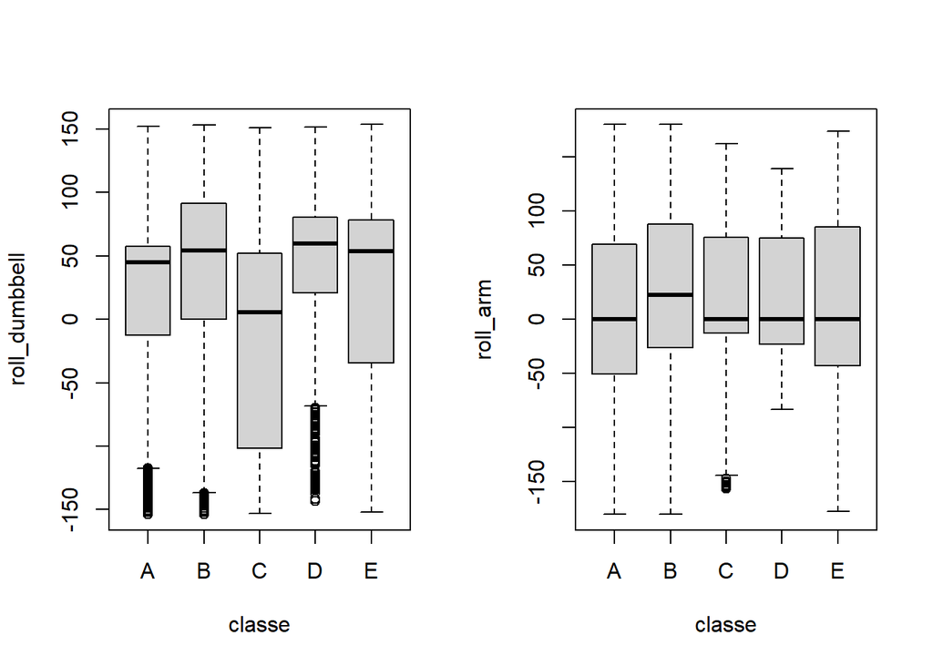

```r
par(mfrow=c(1,2))
boxplot(roll_dumbbell ~ classe, data = pml_training)
boxplot(roll_arm ~ classe, data = pml_training)
```

```r
library(dplyr)
subset_training <- select(pml_training, c("user_name","total_accel_arm","roll_dumbbell","pitch_dumbbell","yaw_dumbbell","total_accel_dumbbell","roll_forearm","pitch_forearm", "classe"))
str(subset_training)
```

```
## 'data.frame':    19622 obs. of  9 variables:
##  $ user_name           : chr  "carlitos" "carlitos" "carlitos" "carlitos" ...
##  $ total_accel_arm     : int  34 34 34 34 34 34 34 34 34 34 ...
##  $ roll_dumbbell       : num  13.1 13.1 12.9 13.4 13.4 ...
##  $ pitch_dumbbell      : num  -70.5 -70.6 -70.3 -70.4 -70.4 ...
##  $ yaw_dumbbell        : num  -84.9 -84.7 -85.1 -84.9 -84.9 ...
##  $ total_accel_dumbbell: int  37 37 37 37 37 37 37 37 37 37 ...
##  $ roll_forearm        : num  28.4 28.3 28.3 28.1 28 27.9 27.9 27.8 27.7 27.7 ...
##  $ pitch_forearm       : num  -63.9 -63.9 -63.9 -63.9 -63.9 -63.9 -63.9 -63.8 -63.8 -63.8 ...
##  $ classe              : chr  "A" "A" "A" "A" ...
```

## Building the model

```r
library(caret)
Sys.time()
```

```
## [1] "2021-06-16 21:39:36 CDT"
```

```r
rf.fit <- train(classe ~ ., method="rf", data=subset_training, trControl = trainControl(method="cv"),number=12)
Sys.time()
```

```
## [1] "2021-06-16 21:47:02 CDT"
```

```r
rf.fit
```

```
## Random Forest
##
## 19622 samples
##     8 predictor
##     5 classes: 'A', 'B', 'C', 'D', 'E'
##
## No pre-processing
## Resampling: Cross-Validated (10 fold)
## Summary of sample sizes: 17660, 17661, 17659, 17659, 17661, 17659, ...
## Resampling results across tuning parameters:
##
##   mtry  Accuracy   Kappa
##    2    0.8283537  0.7815004
##    7    0.8818666  0.8504142
##   12    0.8719801  0.8379127
##
## Accuracy was used to select the optimal model using the largest value.
## The final value used for the model was mtry = 7.
```

Had the model been less accurate, an alternative approach would have been to use Model Ensembling, but this time it won’t be necessary.

## Testing the model

Finally we test the model, with the unused data set containing only the variables chosen for the model. Our goal is to correctly predict 17 out of 20 results (85%).

```r
subset_testing <- select(pml_testing, c("user_name","total_accel_arm","roll_dumbbell","pitch_dumbbell","yaw_dumbbell","total_accel_dumbbell","roll_forearm","pitch_forearm", "problem_id"))

pred <- predict(rf.fit, subset_testing)
```

Fortunately, the model was able to predict correctly 19 out of 20 results. The only wrong prediction was #7.

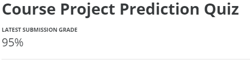

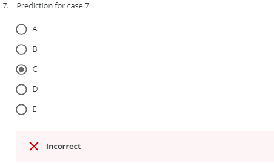